# Lab 06 - Permutational Testing in Regression

Nonparametric statistics ay 2021/2022

2021/10/15

*Disclaimer: The present material has been slightly adapted from the original R script prepared by me for the a.y. 2020/2021 Nonparametric statistics course. I hereby assume responsibility for any error that may be present in this document, I do apologise for them and invite you to let me know.*

```r
set.seed(1992)
n <- 30
B=1000
```

```r
# covariate values
x1 <- runif(n,0,10)
x2 <- (1:n)/5
x3 <- rnorm(n,5,5)


# generating model
b0 <- 2
b1 <- 3
b2 <- -2
b3 <- 0
Y <- b0 + b1*x1 + b2*x2 + b3*x3 + stabledist::rstable(n,1.2,0)
```

Let’s run some plots…

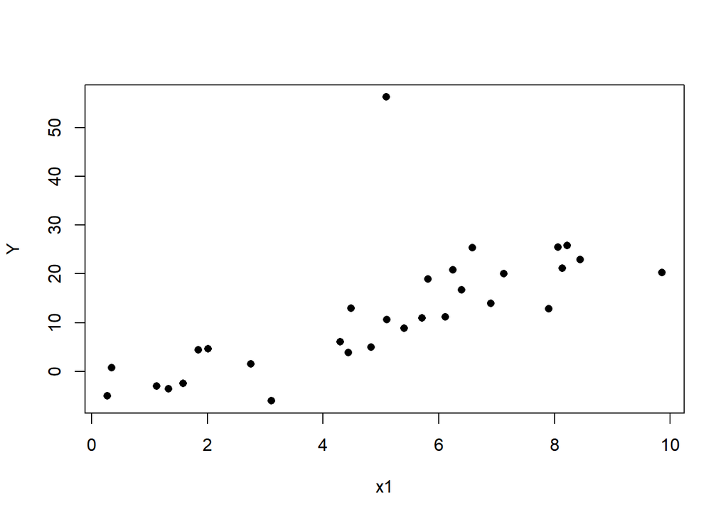

```r
plot(x1,Y,pch=16)
```

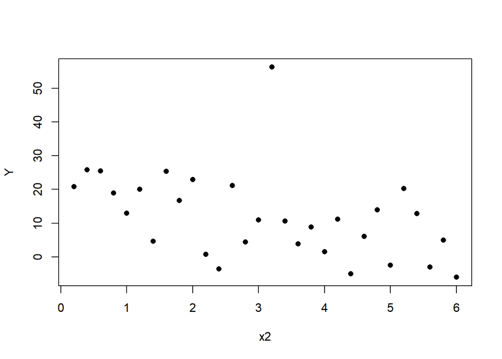

```r
plot(x2,Y,pch=16)
```

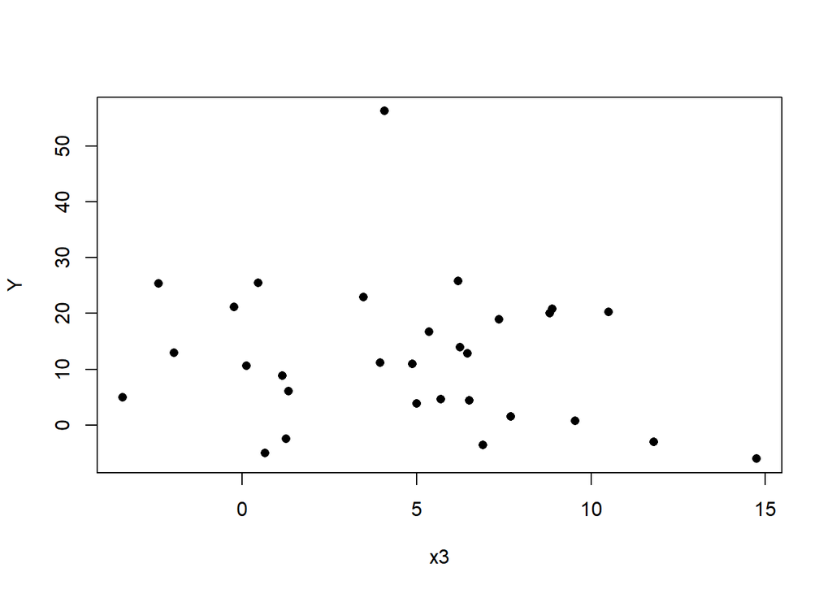

```r
plot(x3,Y,pch=16)
```

And, let’s see how parametric inference behaves in this case (spoiler alert, badly)

```r
# parametric inference
result <- lm(Y ~ x1 + x2 + x3)
summary(result)
```

```
##
## Call:
## lm(formula = Y ~ x1 + x2 + x3)
##
## Residuals:
##    Min     1Q Median     3Q    Max
## -5.979 -2.335 -1.737 -0.260 44.004
##
## Coefficients:
##             Estimate Std. Error t value Pr(>|t|)
## (Intercept)   5.2154     5.5706   0.936 0.357767
## x1            2.9268     0.6586   4.444 0.000146 ***
## x2           -2.1821     0.9874  -2.210 0.036115 *
## x3           -0.2114     0.3895  -0.543 0.591947
## ---
## Signif. codes:  0 '***' 0.001 '**' 0.01 '*' 0.05 '.' 0.1 ' ' 1
##
## Residual standard error: 9.07 on 26 degrees of freedom
## Multiple R-squared:  0.5553, Adjusted R-squared:  0.504
## F-statistic: 10.82 on 3 and 26 DF,  p-value: 8.522e-05
```

How do I behave in this case, permutationally?

Let’s start with a global test. In this case my test statistic is:

```r
T0_glob <- summary(result)$f[1]
T0_glob
```

```
##    value
## 10.82281
```

The permutation scheme to use for the global model is basically, to permute the responses… so:

```r
T_H0glob <- numeric(B)

for(perm in 1:B){
  permutazione <- sample(n)

  Y.perm.glob <- Y[permutazione]
  T_H0glob[perm] <- summary(lm(Y.perm.glob ~ x1 + x2 + x3))$f[1]

}

sum(T_H0glob>=T0_glob)/B
```

```
## [1] 0
```

Ok, the model is significant, let’s go ahead with the other tests… The three test statistics are…

```r
T0_x1 <- abs(summary(result)$coefficients[2,3])
T0_x1
```

```
## [1] 4.443953
```

```r
T0_x2 <- abs(summary(result)$coefficients[3,3])
T0_x2
```

```
## [1] 2.209965
```

```r
T0_x3 <- abs(summary(result)$coefficients[4,3])
T0_x3
```

```
## [1] 0.5427167
```

And, let’s compute the residuals under $H_0$ for the three hypotheses

```r
regr.H01 <- lm(Y ~ x2 + x3)
residui.H01 <- regr.H01$residuals

regr.H02 <- lm(Y ~ x1 + x3)
residui.H02 <- regr.H02$residuals

regr.H03 <- lm(Y ~ x1 + x2)
residui.H03 <- regr.H03$residuals
```

Now, let’s compute the distribution

```r
 T_H01 <- T_H02 <- T_H03 <- numeric(B)

for(perm in 1:B){
  permutazione <- sample(n)

  residui.H01.perm <- residui.H01[permutazione]
  Y.perm.H01 <- regr.H01$fitted + residui.H01.perm
  T_H01[perm] <- abs(summary(lm(Y.perm.H01 ~ x1 + x2 + x3))$coefficients[2,3])

  residui.H02.perm <- residui.H02[permutazione]
  Y.perm.H02 <- regr.H02$fitted + residui.H02.perm
  T_H02[perm] <- abs(summary(lm(Y.perm.H02 ~ x1 + x2 + x3))$coefficients[3,3])

  residui.H03.perm <- residui.H03[permutazione]
  Y.perm.H03 <- regr.H03$fitted + residui.H03.perm
  T_H03[perm] <- abs(summary(lm(Y.perm.H03 ~ x1 + x2 + x3))$coefficients[4,3])

}

sum(T_H01>=T0_x1)/B
```

```
## [1] 0.001
```

```r
sum(T_H02>=T0_x2)/B
```

```
## [1] 0.016
```

```r
sum(T_H03>=T0_x3)/B
```

```
## [1] 0.61
```